# Welcome to ‘Introduction to Data Visualization in R’!

This course is specifically designed for beginners and people with no coding experience. It covers setting up R/RStudio, the basics of data visualisation and compound figure design as well as data transformation using the R `tidyverse`.

## Synopsis of the course

1. Installation of R, Rstudio and the required R libraries (part 1; pre-course preparation, no presentation);
2. Data visualisation with `ggplot2` (part 2);
3. Compound figures with `cowplot` (part 3);
4. Data transformation with `dplyr` (part 4).

To follow the course, start with part 1 (R-course-part1-installation.pdf), which explains how to set up R/RStudio, then get started with the second part by opening the .Rmd file (R-course-part2-ggplot.Rmd) in RStudio and the .html file (R-course-part2-ggplot-presentation.html) in a browser.

## Course material

The following repository contains course notes and analyses scripts combined in Rmd, R notebooks and pdf files. In addition, the course presentations are provided as html files.

The course contains exercises for each section, both in the course notes and the presentation. Solutions to the exercises can be found in the presentation. The data to run the examples is stored in the ‘data’ directory. Figures created throughout the course are stored in the ‘results’ directory.

## Access the course material

You can either clone the repository or, if you are unfamiliar with git/github, simply click the green ‘clone or download’ button and choose the option to download the material as a .zip folder.

This course was initally run as part of the *Cold Spring Harbor Laboratory career development series*. It was designed and taught by Hannah V. Meyer, faculty at Cold Spring Harbor Laboratory. References for data and adapted figures as indicated.

## Evaluations

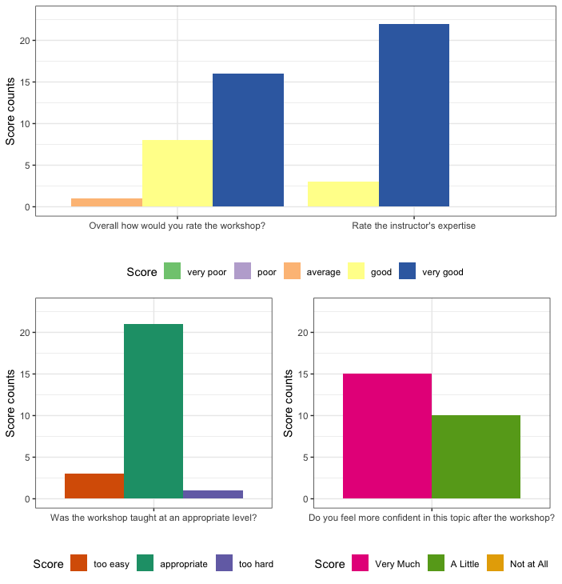